# NYPD Shooting Incident Data

2024-03-04

Import NYPD shooting data and view first few rows

```
##   INCIDENT_KEY OCCUR_DATE OCCUR_TIME     BORO LOC_OF_OCCUR_DESC PRECINCT
## 1    228798151 2021-05-27   21:30:00   QUEENS                        105
## 2    137471050 2014-06-27   17:40:00    BRONX                         40
## 3    147998800 2015-11-21   03:56:00   QUEENS                        108
## 4    146837977 2015-10-09   18:30:00    BRONX                         44
## 5     58921844 2009-02-19   22:58:00    BRONX                         47
## 6    219559682 2020-10-21   21:36:00 BROOKLYN                         81
##   JURISDICTION_CODE LOC_CLASSFCTN_DESC LOCATION_DESC STATISTICAL_MURDER_FLAG
## 1                 0                                                    false
## 2                 0                                                    false
## 3                 0                                                     true
## 4                 0                                                    false
## 5                 0                                                     true
## 6                 0                                                     true
##   PERP_AGE_GROUP PERP_SEX PERP_RACE VIC_AGE_GROUP VIC_SEX       VIC_RACE
## 1                                           18-24       M          BLACK
## 2                                           18-24       M          BLACK
## 3                                           25-44       M          WHITE
## 4                                             <18       M WHITE HISPANIC
## 5          25-44        M     BLACK         45-64       M          BLACK
## 6                                           25-44       M          BLACK
```

Making a histogram of when in the year incidents occur, binned by month

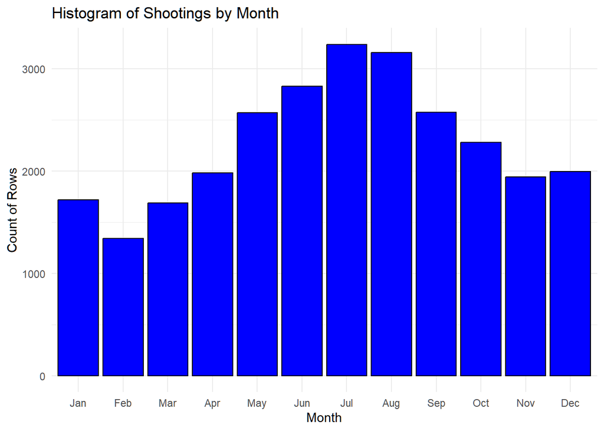

```r
# Extract month from OCCUR_DATE
nypd_shooting_data$MONTH <- format(nypd_shooting_data$OCCUR_DATE, "%m")

# Create a histogram with month as the bin
ggplot(nypd_shooting_data, aes(x = MONTH)) +
  geom_histogram(stat = "count", fill = "blue", color = "black") +
  scale_x_discrete(limits = sprintf("%02d", 1:12), labels = month.abb) +
  labs(title = "Histogram of Shootings by Month",
       x = "Month",
       y = "Count of Rows") +
  theme_minimal()
```

Since July is shown as the peak month for shootings, I want to see which months have significantly fewer shootings. To do this, I use a simple z-test for proportions that uses the proportion of shootings in july/shootings that month. The output is a table showing p-values for each month.

```r
# nypd_shooting_data$MONTH is already created with format(nypd_shooting_data$OCCUR_DATE, "%m") in the previous cell

# Counting the number of shootings per month
shootings_per_month <- nypd_shooting_data %>%
  group_by(MONTH) %>%
  summarise(Shootings = n()) %>%
  mutate(Month_Name = month.abb[as.numeric(MONTH)])  # Convert numeric MONTH to abbreviated month names

# grab shootings count for July
july_shootings <- shootings_per_month$Shootings[shootings_per_month$Month_Name == "Jul"]

# total shootings
total_shootings <- sum(shootings_per_month$Shootings)

# Define proportion of shootings for July
july_proportion <- july_shootings / total_shootings

# one-sample Z-tests for proportions comparing each month to July
shootings_per_month$Z_test_p_value <- apply(shootings_per_month, 1, function(x) {
  month_shootings <- as.numeric(x["Shootings"])
  month_proportion <- month_shootings / total_shootings

  if (x["Month_Name"] == "Jul") {
    return(1)  # No test needed for July itself. Return p-value of 1 for "not applicable"
  } else {
    # Calculate Z statistic for proportion difference
    prop_diff <- month_proportion - july_proportion
    standard_error <- sqrt(july_proportion * (1 - july_proportion) / total_shootings)
    z_value <- prop_diff / standard_error
    # Calculate and return p-value
    return(pnorm(z_value))  # One-tailed test since we want to see if it's less than july
  }
})

print(shootings_per_month[, c("Month_Name", "Shootings", "Z_test_p_value")])
```

```
## # A tibble: 12 × 3
##    Month_Name Shootings Z_test_p_value
##    <chr>          <int>          <dbl>
##  1 Jan             1716      7.99e-179
##  2 Feb             1340      9.36e-277
##  3 Mar             1688      2.24e-185
##  4 Apr             1983      2.50e-122
##  5 May             2571      4.50e- 36
##  6 Jun             2829      9.61e- 15
##  7 Jul             3238      1   e+  0
##  8 Aug             3156      6.24e-  2
##  9 Sep             2572      5.70e- 36
## 10 Oct             2279      2.37e- 72
## 11 Nov             1944      6.63e-130
## 12 Dec             1996      7.45e-120
```

Making histograms by age bucket to identify any association between perpetrator age group and victim age group

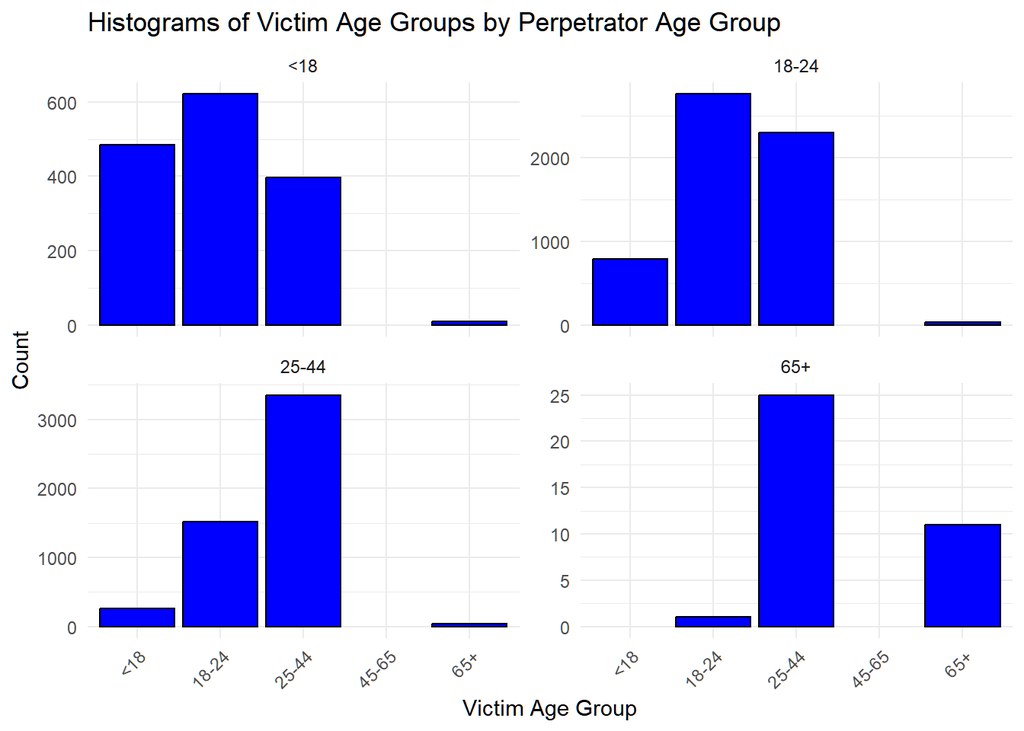

```r
# Filter into valid age groups only
valid_age_groups <- c("<18", "18-24", "25-44", "45-65", "65+")
age_filtered_data <- nypd_shooting_data[
  nypd_shooting_data$PERP_AGE_GROUP %in% valid_age_groups &
  nypd_shooting_data$VIC_AGE_GROUP %in% valid_age_groups, ]


ggplot(age_filtered_data, aes(x = VIC_AGE_GROUP)) +
  geom_histogram(stat = "count", fill = "blue", color = "black") +
  facet_wrap(~ PERP_AGE_GROUP, scales = "free_y") +
  scale_x_discrete(limits = valid_age_groups) +
  labs(title = "Histograms of Victim Age Groups by Perpetrator Age Group",
       x = "Victim Age Group",
       y = "Count") +
  theme_minimal() +
  theme(axis.text.x = element_text(angle = 45, hjust = 1))
```

Model to predict victim age based on perpetrator age.

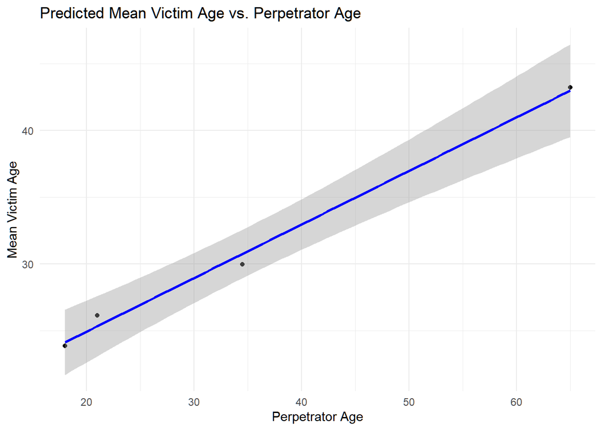

```r
# To build a model based on age, first need to convert age bracket strings to numeric.
# This converts the values to numeric values based on age group mean (manually computed)
# 18 is used for the <18 age group and 65 is used for the 65+ age group since there is no mean for an uncapped range
nypd_shooting_data$PERP_AGE <- as.numeric(ifelse(nypd_shooting_data$PERP_AGE_GROUP == "<18", 18,
                                                 ifelse(nypd_shooting_data$PERP_AGE_GROUP == "18-24", 21,
                                                        ifelse(nypd_shooting_data$PERP_AGE_GROUP == "25-44", 34.5,
                                                               ifelse(nypd_shooting_data$PERP_AGE_GROUP == "45-65", 55,
                                                                      ifelse(nypd_shooting_data$PERP_AGE_GROUP == "65+", 65, NA))))))

nypd_shooting_data$VIC_AGE <- as.numeric(ifelse(nypd_shooting_data$VIC_AGE_GROUP == "<18", 18,
                                                ifelse(nypd_shooting_data$VIC_AGE_GROUP == "18-24", 21,
                                                       ifelse(nypd_shooting_data$VIC_AGE_GROUP == "25-44", 34.5,
                                                              ifelse(nypd_shooting_data$VIC_AGE_GROUP == "45-65", 55,
                                                                     ifelse(nypd_shooting_data$VIC_AGE_GROUP == "65+", 65, NA))))))

# Filter out rows with NA for PERP_AGE or VIC_AGE. Can only use numeric data
nypd_shooting_data <- nypd_shooting_data %>% filter(!is.na(PERP_AGE) & !is.na(VIC_AGE))

# Calculate mean victim age for each perpetrator age
# Using summary metric of victim age as predictor for perp age group targets
mean_victim_age_by_perp_age <- nypd_shooting_data %>%
  group_by(PERP_AGE) %>%
  summarise(Mean_Victim_Age = mean(VIC_AGE, na.rm = TRUE))

# builds linear model for predicting victim age based on perpetrator age
lm_model <- lm(Mean_Victim_Age ~ PERP_AGE, data = mean_victim_age_by_perp_age)

# Plots linear model chart
ggplot(mean_victim_age_by_perp_age, aes(x = PERP_AGE, y = Mean_Victim_Age)) +
  geom_point() +
  geom_smooth(method = "lm", formula = y ~ x, color = "blue") +
  labs(title = "Predicted Mean Victim Age vs. Perpetrator Age",
       x = "Perpetrator Age",
       y = "Mean Victim Age") +
  theme_minimal()
```

```r
# Prints summary of the model to inspect details
print(summary(lm_model))
```

```
##
## Call:
## lm(formula = Mean_Victim_Age ~ PERP_AGE, data = mean_victim_age_by_perp_age)
##
## Residuals:
##       1       2       3       4
## -0.2606  0.8255 -0.7893  0.2244
##
## Coefficients:
##             Estimate Std. Error t value Pr(>|t|)
## (Intercept) 16.91970    0.89090   18.99  0.00276 **
## PERP_AGE     0.40090    0.02267   17.69  0.00318 **
## ---
## Signif. codes:  0 '***' 0.001 '**' 0.01 '*' 0.05 '.' 0.1 ' ' 1
##
## Residual standard error: 0.8434 on 2 degrees of freedom
## Multiple R-squared:  0.9936, Adjusted R-squared:  0.9905
## F-statistic: 312.9 on 1 and 2 DF,  p-value: 0.003181
```

Conclusions:

My two analyses above stratify shooting incidents by two variables that may inform some sociological basis for the incidents.

To group by time, I generated a histogram binned by month. Interestingly, there seems to be a significantly higher number of shootings in the summer months than in winter. A possible explanation for this observation may simply arise from the weather. The winter months in New York can be quite cold so people are less likely to be out and about. This seems to suggest that the presence of face-to-face interaction increases odds of violent conflict. There is, however, much room for bias here. I make the (perhaps unjustified) assumption that shooting incidents arise from social interaction between people. It is also quite possible that having more people around increases convenience for violent crime that does not involve any sort of social situation. Regardless, it does seem valid to infer that shooting incidents follow weather patterns. It would be very interesting to have a day-to-day weather column to verify this claim by binning incidents by weather status (i.e. rainy/snowy/sunny).

To quantify and model differences in shooting activity, I used my histogram visualization to identify the peak shooting month. I found this to be July. I used this as the basis to identify if all other months had a significantly lower number of shootings. This test was done using a z-test for proportions. Using a p-value of 0.05, only August failed to show a significantly lower number of shootings. This means that shooting activity is in fact lower outside of the summer months. This result could be used to encourage police forces to focus resources on increasing protective services during the summer months.

The model developed here predicts victim age based on perpetrator age. The result is a surprisingly strong correlation. This data could be used to focus development of preventative resources for resolving conflict. I am inferring here that the strong correlation reveals social connections between victims and perpetrators due to closeness in age. This is a strong source of bias, but if correct, preventative resources could focus on resolving conflicts between peers.